# Risk Factor Analysis

## Outcome Variable

**Outcome Variable:** stunted

## Predictor Variables

**Intervention Variable:** impfloor

**Adjustment Set:**

unadjusted

## Stratifying Variables

The analysis was stratified on these variable(s):

- agecat
- studyid
- country

## Data Summary

| agecat | studyid | country | impfloor | stunted | n_cell | n |
| --- | --- | --- | --- | --- | --- | --- |
| Birth | CMC-V-BCS-2002 | INDIA | 1 | 0 | 58 | 72 |
| Birth | CMC-V-BCS-2002 | INDIA | 1 | 1 | 14 | 72 |
| Birth | CMC-V-BCS-2002 | INDIA | 0 | 0 | 0 | 72 |
| Birth | CMC-V-BCS-2002 | INDIA | 0 | 1 | 0 | 72 |
| Birth | CONTENT | PERU | 1 | 0 | 2 | 2 |
| Birth | CONTENT | PERU | 1 | 1 | 0 | 2 |
| Birth | CONTENT | PERU | 0 | 0 | 0 | 2 |
| Birth | CONTENT | PERU | 0 | 1 | 0 | 2 |
| Birth | GMS-Nepal | NEPAL | 1 | 0 | 91 | 544 |
| Birth | GMS-Nepal | NEPAL | 1 | 1 | 9 | 544 |
| Birth | GMS-Nepal | NEPAL | 0 | 0 | 361 | 544 |
| Birth | GMS-Nepal | NEPAL | 0 | 1 | 83 | 544 |
| Birth | IRC | INDIA | 1 | 0 | 255 | 287 |
| Birth | IRC | INDIA | 1 | 1 | 32 | 287 |
| Birth | IRC | INDIA | 0 | 0 | 0 | 287 |
| Birth | IRC | INDIA | 0 | 1 | 0 | 287 |
| Birth | MAL-ED | BANGLADESH | 1 | 0 | 161 | 213 |
| Birth | MAL-ED | BANGLADESH | 1 | 1 | 35 | 213 |
| Birth | MAL-ED | BANGLADESH | 0 | 0 | 15 | 213 |
| Birth | MAL-ED | BANGLADESH | 0 | 1 | 2 | 213 |
| Birth | MAL-ED | BRAZIL | 1 | 0 | 49 | 60 |
| Birth | MAL-ED | BRAZIL | 1 | 1 | 9 | 60 |
| Birth | MAL-ED | BRAZIL | 0 | 0 | 2 | 60 |
| Birth | MAL-ED | BRAZIL | 0 | 1 | 0 | 60 |
| Birth | MAL-ED | INDIA | 1 | 0 | 27 | 41 |
| Birth | MAL-ED | INDIA | 1 | 1 | 8 | 41 |
| Birth | MAL-ED | INDIA | 0 | 0 | 6 | 41 |
| Birth | MAL-ED | INDIA | 0 | 1 | 0 | 41 |
| Birth | MAL-ED | NEPAL | 1 | 0 | 8 | 25 |
| Birth | MAL-ED | NEPAL | 1 | 1 | 1 | 25 |

[output cut: 138 more lines]

The following strata were considered:

- agecat: 24 months, studyid: CMC-V-BCS-2002, country: INDIA
- agecat: 24 months, studyid: CONTENT, country: PERU
- agecat: 24 months, studyid: GMS-Nepal, country: NEPAL
- agecat: 24 months, studyid: IRC, country: INDIA
- agecat: 24 months, studyid: MAL-ED, country: BANGLADESH
- agecat: 24 months, studyid: MAL-ED, country: BRAZIL
- agecat: 24 months, studyid: MAL-ED, country: INDIA
- agecat: 24 months, studyid: MAL-ED, country: NEPAL
- agecat: 24 months, studyid: MAL-ED, country: PERU
- agecat: 24 months, studyid: MAL-ED, country: SOUTH AFRICA
- agecat: 24 months, studyid: MAL-ED, country: TANZANIA, UNITED REPUBLIC OF
- agecat: 24 months, studyid: NIH-Birth, country: BANGLADESH
- agecat: 24 months, studyid: NIH-Crypto, country: BANGLADESH
- agecat: 24 months, studyid: PROVIDE, country: BANGLADESH
- agecat: 6 months, studyid: CMC-V-BCS-2002, country: INDIA
- agecat: 6 months, studyid: CONTENT, country: PERU
- agecat: 6 months, studyid: GMS-Nepal, country: NEPAL
- agecat: 6 months, studyid: IRC, country: INDIA
- agecat: 6 months, studyid: MAL-ED, country: BANGLADESH
- agecat: 6 months, studyid: MAL-ED, country: BRAZIL
- agecat: 6 months, studyid: MAL-ED, country: INDIA
- agecat: 6 months, studyid: MAL-ED, country: NEPAL
- agecat: 6 months, studyid: MAL-ED, country: PERU
- agecat: 6 months, studyid: MAL-ED, country: SOUTH AFRICA
- agecat: 6 months, studyid: MAL-ED, country: TANZANIA, UNITED REPUBLIC OF
- agecat: 6 months, studyid: NIH-Birth, country: BANGLADESH
- agecat: 6 months, studyid: NIH-Crypto, country: BANGLADESH
- agecat: 6 months, studyid: PROVIDE, country: BANGLADESH
- agecat: Birth, studyid: CMC-V-BCS-2002, country: INDIA
- agecat: Birth, studyid: CONTENT, country: PERU
- agecat: Birth, studyid: GMS-Nepal, country: NEPAL
- agecat: Birth, studyid: IRC, country: INDIA
- agecat: Birth, studyid: MAL-ED, country: BANGLADESH
- agecat: Birth, studyid: MAL-ED, country: BRAZIL
- agecat: Birth, studyid: MAL-ED, country: INDIA
- agecat: Birth, studyid: MAL-ED, country: NEPAL
- agecat: Birth, studyid: MAL-ED, country: PERU
- agecat: Birth, studyid: MAL-ED, country: SOUTH AFRICA
- agecat: Birth, studyid: MAL-ED, country: TANZANIA, UNITED REPUBLIC OF
- agecat: Birth, studyid: NIH-Birth, country: BANGLADESH
- agecat: Birth, studyid: NIH-Crypto, country: BANGLADESH
- agecat: Birth, studyid: PROVIDE, country: BANGLADESH

### Dropped Strata

Some strata were dropped due to rare outcomes:

- agecat: Birth, studyid: CMC-V-BCS-2002, country: INDIA
- agecat: Birth, studyid: CONTENT, country: PERU
- agecat: Birth, studyid: IRC, country: INDIA
- agecat: Birth, studyid: MAL-ED, country: BANGLADESH
- agecat: Birth, studyid: MAL-ED, country: BRAZIL
- agecat: Birth, studyid: MAL-ED, country: INDIA
- agecat: Birth, studyid: MAL-ED, country: NEPAL
- agecat: Birth, studyid: MAL-ED, country: SOUTH AFRICA
- agecat: Birth, studyid: MAL-ED, country: TANZANIA, UNITED REPUBLIC OF
- agecat: Birth, studyid: PROVIDE, country: BANGLADESH
- agecat: 6 months, studyid: CMC-V-BCS-2002, country: INDIA
- agecat: 6 months, studyid: CONTENT, country: PERU
- agecat: 6 months, studyid: IRC, country: INDIA
- agecat: 6 months, studyid: MAL-ED, country: BANGLADESH
- agecat: 6 months, studyid: MAL-ED, country: BRAZIL
- agecat: 6 months, studyid: MAL-ED, country: INDIA
- agecat: 6 months, studyid: MAL-ED, country: SOUTH AFRICA
- agecat: 6 months, studyid: MAL-ED, country: TANZANIA, UNITED REPUBLIC OF
- agecat: 24 months, studyid: CMC-V-BCS-2002, country: INDIA
- agecat: 24 months, studyid: CONTENT, country: PERU
- agecat: 24 months, studyid: IRC, country: INDIA
- agecat: 24 months, studyid: MAL-ED, country: BRAZIL
- agecat: 24 months, studyid: MAL-ED, country: TANZANIA, UNITED REPUBLIC OF

## Methods Detail

We’re interested in the causal parameters $E[Y_a]$ for all values of $a \in \mathcal{A}$. These parameters represent the mean outcome if, possibly contrary to fact, we intervened to set all units to have $A=a$. Under the randomization and positivity assumptions, these are identified by the statistical parameters $\psi_a=E_W[E_{Y|A,W}(Y|A=a,W)]$. In addition, we’re interested in the mean of $Y$, $E[Y]$ under no intervention (the observed mean). We will estimate these parameters by using SuperLearner to fit the relevant likelihood factors – $E_{Y|A,W}(Y|A=a,W)$ and $p(A=a|W)$, and then updating our likelihood fit using a joint TMLE.

For unadjusted analyses ($W=\{\}$), initial likelihoods were estimated using Lrnr_glm to estimate the simple $E(Y|A)$ and Lrnr_mean to estimate $p(A)$. For adjusted analyses, a small library containing Lrnr_glmnet, Lrnr_xgboost, and Lrnr_mean was used.

Having estimated these parameters, we will then use the delta method to estimate relative risks and attributable risks relative to a prespecified baseline level of $A$.

# Results Detail

## Results Plots

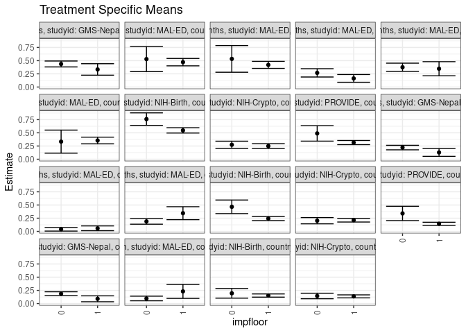

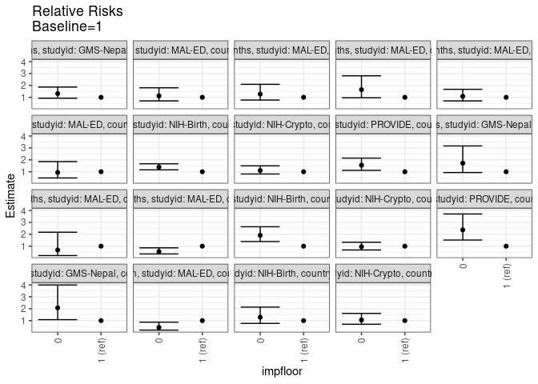

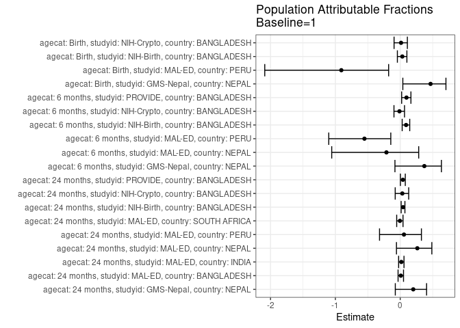

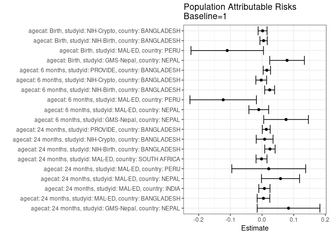

## Results Table

### Parameter: TSM

| agecat | studyid | country | intervention_level | baseline_level | estimate | ci_lower | ci_upper |
| --- | --- | --- | --- | --- | --- | --- | --- |
| Birth | GMS-Nepal | NEPAL | 1 | NA | 0.0900000 | 0.0338578 | 0.1461422 |
| Birth | GMS-Nepal | NEPAL | 0 | NA | 0.1869369 | 0.1506403 | 0.2232335 |
| Birth | MAL-ED | PERU | 1 | NA | 0.2307692 | 0.0982297 | 0.3633088 |
| Birth | MAL-ED | PERU | 0 | NA | 0.0965909 | 0.0528473 | 0.1403345 |
| Birth | NIH-Birth | BANGLADESH | 1 | NA | 0.1519700 | 0.1214680 | 0.1824720 |
| Birth | NIH-Birth | BANGLADESH | 0 | NA | 0.1944444 | 0.1029517 | 0.2859372 |
| Birth | NIH-Crypto | BANGLADESH | 1 | NA | 0.1362007 | 0.1077218 | 0.1646797 |
| Birth | NIH-Crypto | BANGLADESH | 0 | NA | 0.1436782 | 0.0915246 | 0.1958318 |
| 6 months | GMS-Nepal | NEPAL | 1 | NA | 0.1282051 | 0.0539283 | 0.2024820 |
| 6 months | GMS-Nepal | NEPAL | 0 | NA | 0.2203857 | 0.1776963 | 0.2630750 |
| 6 months | MAL-ED | NEPAL | 1 | NA | 0.0582524 | 0.0129205 | 0.1035843 |
| 6 months | MAL-ED | NEPAL | 0 | NA | 0.0396825 | 0.0055223 | 0.0738427 |
| 6 months | MAL-ED | PERU | 1 | NA | 0.3448276 | 0.2222761 | 0.4673791 |
| 6 months | MAL-ED | PERU | 0 | NA | 0.1886792 | 0.1359144 | 0.2414440 |
| 6 months | NIH-Birth | BANGLADESH | 1 | NA | 0.2431866 | 0.2046512 | 0.2817219 |
| 6 months | NIH-Birth | BANGLADESH | 0 | NA | 0.4655172 | 0.3370255 | 0.5940089 |
| 6 months | NIH-Crypto | BANGLADESH | 1 | NA | 0.2122905 | 0.1776796 | 0.2469014 |
| 6 months | NIH-Crypto | BANGLADESH | 0 | NA | 0.2022472 | 0.1431975 | 0.2612969 |
| 6 months | PROVIDE | BANGLADESH | 1 | NA | 0.1436266 | 0.1144772 | 0.1727759 |
| 6 months | PROVIDE | BANGLADESH | 0 | NA | 0.3404255 | 0.2048436 | 0.4760075 |
| 24 months | GMS-Nepal | NEPAL | 1 | NA | 0.3333333 | 0.2243006 | 0.4423661 |
| 24 months | GMS-Nepal | NEPAL | 0 | NA | 0.4370861 | 0.3810677 | 0.4931045 |
| 24 months | MAL-ED | BANGLADESH | 1 | NA | 0.4717949 | 0.4015628 | 0.5420269 |
| 24 months | MAL-ED | BANGLADESH | 0 | NA | 0.5294118 | 0.2915812 | 0.7672423 |
| 24 months | MAL-ED | INDIA | 1 | NA | 0.4198113 | 0.3532303 | 0.4863924 |
| 24 months | MAL-ED | INDIA | 0 | NA | 0.5333333 | 0.2803080 | 0.7863586 |
| 24 months | MAL-ED | NEPAL | 1 | NA | 0.1632653 | 0.0899220 | 0.2366086 |
| 24 months | MAL-ED | NEPAL | 0 | NA | 0.2682927 | 0.1898137 | 0.3467717 |
| 24 months | MAL-ED | PERU | 1 | NA | 0.3469388 | 0.2133295 | 0.4805480 |
| 24 months | MAL-ED | PERU | 0 | NA | 0.3750000 | 0.2978448 | 0.4521552 |
| 24 months | MAL-ED | SOUTH AFRICA | 1 | NA | 0.3545455 | 0.2911994 | 0.4178915 |
| 24 months | MAL-ED | SOUTH AFRICA | 0 | NA | 0.3333333 | 0.1151006 | 0.5515661 |
| 24 months | NIH-Birth | BANGLADESH | 1 | NA | 0.5464191 | 0.4961065 | 0.5967317 |
| 24 months | NIH-Birth | BANGLADESH | 0 | NA | 0.7600000 | 0.6414819 | 0.8785181 |
| 24 months | NIH-Crypto | BANGLADESH | 1 | NA | 0.2485549 | 0.2029730 | 0.2941368 |
| 24 months | NIH-Crypto | BANGLADESH | 0 | NA | 0.2738095 | 0.2063154 | 0.3413036 |
| 24 months | PROVIDE | BANGLADESH | 1 | NA | 0.3151970 | 0.2757209 | 0.3546731 |
| 24 months | PROVIDE | BANGLADESH | 0 | NA | 0.4888889 | 0.3427114 | 0.6350664 |

### Parameter: E(Y)

| agecat | studyid | country | intervention_level | baseline_level | estimate | ci_lower | ci_upper |
| --- | --- | --- | --- | --- | --- | --- | --- |
| Birth | GMS-Nepal | NEPAL | NA | NA | 0.1691176 | 0.1375885 | 0.2006468 |
| Birth | MAL-ED | PERU | NA | NA | 0.1209302 | 0.0772464 | 0.1646140 |
| Birth | NIH-Birth | BANGLADESH | NA | NA | 0.1570248 | 0.1280099 | 0.1860397 |
| Birth | NIH-Crypto | BANGLADESH | NA | NA | 0.1379781 | 0.1129774 | 0.1629789 |
| 6 months | GMS-Nepal | NEPAL | NA | NA | 0.2040816 | 0.1664236 | 0.2417397 |
| 6 months | MAL-ED | NEPAL | NA | NA | 0.0480349 | 0.0202781 | 0.0757918 |
| 6 months | MAL-ED | PERU | NA | NA | 0.2222222 | 0.1725409 | 0.2719036 |
| 6 months | NIH-Birth | BANGLADESH | NA | NA | 0.2672897 | 0.2297549 | 0.3048246 |
| 6 months | NIH-Crypto | BANGLADESH | NA | NA | 0.2097902 | 0.1799252 | 0.2396552 |
| 6 months | PROVIDE | BANGLADESH | NA | NA | 0.1589404 | 0.1297581 | 0.1881227 |
| 24 months | GMS-Nepal | NEPAL | NA | NA | 0.4171123 | 0.3670728 | 0.4671518 |
| 24 months | MAL-ED | BANGLADESH | NA | NA | 0.4764151 | 0.4090254 | 0.5438047 |
| 24 months | MAL-ED | INDIA | NA | NA | 0.4273128 | 0.3628178 | 0.4918077 |
| 24 months | MAL-ED | NEPAL | NA | NA | 0.2217195 | 0.1668277 | 0.2766112 |
| 24 months | MAL-ED | PERU | NA | NA | 0.3681592 | 0.3013164 | 0.4350020 |
| 24 months | MAL-ED | SOUTH AFRICA | NA | NA | 0.3529412 | 0.2921001 | 0.4137823 |
| 24 months | NIH-Birth | BANGLADESH | NA | NA | 0.5714286 | 0.5244353 | 0.6184219 |
| 24 months | NIH-Crypto | BANGLADESH | NA | NA | 0.2568093 | 0.2190047 | 0.2946140 |
| 24 months | PROVIDE | BANGLADESH | NA | NA | 0.3287197 | 0.2903909 | 0.3670485 |

### Parameter: RR

| agecat | studyid | country | intervention_level | baseline_level | estimate | ci_lower | ci_upper |
| --- | --- | --- | --- | --- | --- | --- | --- |
| Birth | GMS-Nepal | NEPAL | 1 | 1 | 1.0000000 | 1.0000000 | 1.0000000 |
| Birth | GMS-Nepal | NEPAL | 0 | 1 | 2.0770771 | 1.0807333 | 3.9919648 |
| Birth | MAL-ED | PERU | 1 | 1 | 1.0000000 | 1.0000000 | 1.0000000 |
| Birth | MAL-ED | PERU | 0 | 1 | 0.4185606 | 0.2014240 | 0.8697720 |
| Birth | NIH-Birth | BANGLADESH | 1 | 1 | 1.0000000 | 1.0000000 | 1.0000000 |
| Birth | NIH-Birth | BANGLADESH | 0 | 1 | 1.2794925 | 0.7671368 | 2.1340403 |
| Birth | NIH-Crypto | BANGLADESH | 1 | 1 | 1.0000000 | 1.0000000 | 1.0000000 |
| Birth | NIH-Crypto | BANGLADESH | 0 | 1 | 1.0549002 | 0.6938778 | 1.6037614 |
| 6 months | GMS-Nepal | NEPAL | 1 | 1 | 1.0000000 | 1.0000000 | 1.0000000 |
| 6 months | GMS-Nepal | NEPAL | 0 | 1 | 1.7190083 | 0.9332000 | 3.1665123 |
| 6 months | MAL-ED | NEPAL | 1 | 1 | 1.0000000 | 1.0000000 | 1.0000000 |
| 6 months | MAL-ED | NEPAL | 0 | 1 | 0.6812169 | 0.2134571 | 2.1740031 |
| 6 months | MAL-ED | PERU | 1 | 1 | 1.0000000 | 1.0000000 | 1.0000000 |
| 6 months | MAL-ED | PERU | 0 | 1 | 0.5471698 | 0.3481127 | 0.8600515 |
| 6 months | NIH-Birth | BANGLADESH | 1 | 1 | 1.0000000 | 1.0000000 | 1.0000000 |
| 6 months | NIH-Birth | BANGLADESH | 0 | 1 | 1.9142390 | 1.3924288 | 2.6315967 |
| 6 months | NIH-Crypto | BANGLADESH | 1 | 1 | 1.0000000 | 1.0000000 | 1.0000000 |
| 6 months | NIH-Crypto | BANGLADESH | 0 | 1 | 0.9526907 | 0.6819025 | 1.3310109 |
| 6 months | PROVIDE | BANGLADESH | 1 | 1 | 1.0000000 | 1.0000000 | 1.0000000 |
| 6 months | PROVIDE | BANGLADESH | 0 | 1 | 2.3702128 | 1.5158528 | 3.7061042 |
| 24 months | GMS-Nepal | NEPAL | 1 | 1 | 1.0000000 | 1.0000000 | 1.0000000 |
| 24 months | GMS-Nepal | NEPAL | 0 | 1 | 1.3112583 | 0.9228179 | 1.8632042 |
| 24 months | MAL-ED | BANGLADESH | 1 | 1 | 1.0000000 | 1.0000000 | 1.0000000 |
| 24 months | MAL-ED | BANGLADESH | 0 | 1 | 1.1221228 | 0.6990487 | 1.8012472 |
| 24 months | MAL-ED | INDIA | 1 | 1 | 1.0000000 | 1.0000000 | 1.0000000 |
| 24 months | MAL-ED | INDIA | 0 | 1 | 1.2704120 | 0.7703668 | 2.0950365 |
| 24 months | MAL-ED | NEPAL | 1 | 1 | 1.0000000 | 1.0000000 | 1.0000000 |
| 24 months | MAL-ED | NEPAL | 0 | 1 | 1.6432927 | 0.9613983 | 2.8088367 |
| 24 months | MAL-ED | PERU | 1 | 1 | 1.0000000 | 1.0000000 | 1.0000000 |
| 24 months | MAL-ED | PERU | 0 | 1 | 1.0808824 | 0.6984815 | 1.6726379 |
| 24 months | MAL-ED | SOUTH AFRICA | 1 | 1 | 1.0000000 | 1.0000000 | 1.0000000 |
| 24 months | MAL-ED | SOUTH AFRICA | 0 | 1 | 0.9401709 | 0.4769548 | 1.8532602 |
| 24 months | NIH-Birth | BANGLADESH | 1 | 1 | 1.0000000 | 1.0000000 | 1.0000000 |
| 24 months | NIH-Birth | BANGLADESH | 0 | 1 | 1.3908738 | 1.1604790 | 1.6670098 |
| 24 months | NIH-Crypto | BANGLADESH | 1 | 1 | 1.0000000 | 1.0000000 | 1.0000000 |
| 24 months | NIH-Crypto | BANGLADESH | 0 | 1 | 1.1016058 | 0.8102064 | 1.4978100 |
| 24 months | PROVIDE | BANGLADESH | 1 | 1 | 1.0000000 | 1.0000000 | 1.0000000 |
| 24 months | PROVIDE | BANGLADESH | 0 | 1 | 1.5510582 | 1.1216121 | 2.1449318 |

### Parameter: PAR

| agecat | studyid | country | intervention_level | baseline_level | estimate | ci_lower | ci_upper |
| --- | --- | --- | --- | --- | --- | --- | --- |
| Birth | GMS-Nepal | NEPAL | 1 | NA | 0.0791176 | 0.0244621 | 0.1337732 |
| Birth | MAL-ED | PERU | 1 | NA | -0.1098390 | -0.2243028 | 0.0046248 |
| Birth | NIH-Birth | BANGLADESH | 1 | NA | 0.0050548 | -0.0064750 | 0.0165846 |
| Birth | NIH-Crypto | BANGLADESH | 1 | NA | 0.0017774 | -0.0123495 | 0.0159044 |
| 6 months | GMS-Nepal | NEPAL | 1 | NA | 0.0758765 | 0.0052821 | 0.1464709 |
| 6 months | MAL-ED | NEPAL | 1 | NA | -0.0102175 | -0.0414719 | 0.0210369 |
| 6 months | MAL-ED | PERU | 1 | NA | -0.1226054 | -0.2276509 | -0.0175599 |
| 6 months | NIH-Birth | BANGLADESH | 1 | NA | 0.0241031 | 0.0084230 | 0.0397833 |
| 6 months | NIH-Crypto | BANGLADESH | 1 | NA | -0.0025003 | -0.0195428 | 0.0145422 |
| 6 months | PROVIDE | BANGLADESH | 1 | NA | 0.0153138 | 0.0037312 | 0.0268965 |
| 24 months | GMS-Nepal | NEPAL | 1 | NA | 0.0837790 | -0.0152909 | 0.1828488 |
| 24 months | MAL-ED | BANGLADESH | 1 | NA | 0.0046202 | -0.0153770 | 0.0246175 |
| 24 months | MAL-ED | INDIA | 1 | NA | 0.0075015 | -0.0101741 | 0.0251770 |
| 24 months | MAL-ED | NEPAL | 1 | NA | 0.0584542 | -0.0017257 | 0.1186340 |
| 24 months | MAL-ED | PERU | 1 | NA | 0.0212204 | -0.0954659 | 0.1379068 |
| 24 months | MAL-ED | SOUTH AFRICA | 1 | NA | -0.0016043 | -0.0188054 | 0.0155968 |
| 24 months | NIH-Birth | BANGLADESH | 1 | NA | 0.0250095 | 0.0085828 | 0.0414361 |
| 24 months | NIH-Crypto | BANGLADESH | 1 | NA | 0.0082544 | -0.0183852 | 0.0348941 |
| 24 months | PROVIDE | BANGLADESH | 1 | NA | 0.0135227 | 0.0011379 | 0.0259075 |

### Parameter: PAF

| agecat | studyid | country | intervention_level | baseline_level | estimate | ci_lower | ci_upper |
| --- | --- | --- | --- | --- | --- | --- | --- |
| Birth | GMS-Nepal | NEPAL | 1 | NA | 0.4678261 | 0.0402469 | 0.7049147 |
| Birth | MAL-ED | PERU | 1 | NA | -0.9082840 | -2.0890152 | -0.1788702 |
| Birth | NIH-Birth | BANGLADESH | 1 | NA | 0.0321912 | -0.0439265 | 0.1027587 |
| Birth | NIH-Crypto | BANGLADESH | 1 | NA | 0.0128819 | -0.0949814 | 0.1101200 |
| 6 months | GMS-Nepal | NEPAL | 1 | NA | 0.3717949 | -0.0815092 | 0.6351010 |
| 6 months | MAL-ED | NEPAL | 1 | NA | -0.2127096 | -1.0563292 | 0.2848107 |
| 6 months | MAL-ED | PERU | 1 | NA | -0.5517241 | -1.1018571 | -0.1455811 |
| 6 months | NIH-Birth | BANGLADESH | 1 | NA | 0.0901761 | 0.0300719 | 0.1465557 |
| 6 months | NIH-Crypto | BANGLADESH | 1 | NA | -0.0119181 | -0.0964951 | 0.0661352 |
| 6 months | PROVIDE | BANGLADESH | 1 | NA | 0.0963495 | 0.0220027 | 0.1650445 |
| 24 months | GMS-Nepal | NEPAL | 1 | NA | 0.2008547 | -0.0759638 | 0.4064547 |
| 24 months | MAL-ED | BANGLADESH | 1 | NA | 0.0096979 | -0.0331976 | 0.0508125 |
| 24 months | MAL-ED | INDIA | 1 | NA | 0.0175550 | -0.0247338 | 0.0580986 |
| 24 months | MAL-ED | NEPAL | 1 | NA | 0.2636401 | -0.0579426 | 0.4874714 |
| 24 months | MAL-ED | PERU | 1 | NA | 0.0576393 | -0.3191428 | 0.3268024 |
| 24 months | MAL-ED | SOUTH AFRICA | 1 | NA | -0.0045455 | -0.0544841 | 0.0430282 |
| 24 months | NIH-Birth | BANGLADESH | 1 | NA | 0.0437666 | 0.0142257 | 0.0724222 |
| 24 months | NIH-Crypto | BANGLADESH | 1 | NA | 0.0321422 | -0.0773141 | 0.1304777 |
| 24 months | PROVIDE | BANGLADESH | 1 | NA | 0.0411376 | 0.0027310 | 0.0780650 |